# stochLAB

### Band model example

This is an example usage of `band_crm()`. This is for a single species and single set of turbine parameters. This replicates the Band (2012) worksheet. The `stoch_crm()` function wraps around this function, where `band_crm()` acts in essence as a single draw of `stoch_crm()`.

Please note the example runs on fictional data.

```r
# ------------------------------------------------------
# Run with arbitrary parameter values, for illustration
# ------------------------------------------------------

# Setting a dataframe of parameters to draw from
params <- data.frame(
  flight_speed = 13.1,         # Flight speed in m/s
  body_lt = 0.85,              # Body length in m
  wing_span = 1.01,            # Wing span in m
  flight_type = "flapping",    # flapping or gliding flight
  avoid_rt_basic = 0.989,      # avoidance rate for option 1 and 2
  avoid_rt_ext = 0.981,        # extended avoidance rate for option 3 and 4
  noct_activity = 0.5,         # proportion of day birds are inactive
  prop_crh_surv = 0.13,        # proportion of birds at collision risk height (option 1 only)
  prop_upwind = 0.5,           # proportion of flights that are upwind
  rotor_speed = 15,            # rotor speed in m/s
  rotor_radius = 120,          # radius of turbine in m
  blade_width = 5,             # width of turbine blades at thickest point in m
  blade_pitch = 15,            # mean radius pitch in Radians
  n_blades = 3,                # total number of blades per turbine
  hub_height = 150,            # height of hub in m above HAT
  n_turbines = 100,            # number of turbines in the wind farm
  wf_width = 52,               # width across longest section of wind farm
  wf_latitude = 56,            # latitude of centroid of wind farm
  tidal_offset = 2.5,          # mean tidal offset from HAT of the wind farm
  lrg_arr_corr = TRUE          # apply a large array correction?
)

# Monthly bird densities
b_dens <- data.frame(
  month = month.abb,
  dens = runif(12, 0.8, 1.5)
)

# flight height distribution from Johnston et al
gen_fhd_dat <- data.frame(
  height = Johnston_Flight_heights_SOSS$Height,
  prop = Johnston_Flight_heights_SOSS$Gannet.est
)

# monthly operational time of the wind farm
turb_oper <- data.frame(
  month = month.abb,
  prop_oper = runif(12,0.5,0.8)
)


band_crm(
  model_options = c(1,2,3),
  flight_speed = params$flight_speed,
  body_lt = params$body_lt,
  wing_span = params$wing_span,
  flight_type = params$flight_type,
  avoid_rt_basic = params$avoid_rt_basic,
  avoid_rt_ext = params$avoid_rt_ext,
  noct_activity = params$noct_activity,
  prop_crh_surv = params$prop_crh_surv,
  dens_month = b_dens,
  prop_upwind = params$prop_upwind,
  gen_fhd = gen_fhd_dat,
  site_fhd = NULL,  # Option 4 only
  rotor_speed = params$rotor_speed,
  rotor_radius = params$rotor_radius,
  blade_width = params$blade_width,
  blade_pitch = params$blade_pitch,
  n_blades = params$n_blades,
  hub_height = params$hub_height,
  chord_prof = chord_prof_5MW,
  n_turbines = params$n_turbines,
  turb_oper_month = turb_oper,
  wf_width = params$wf_width,
  wf_latitude = params$wf_latitude,
  tidal_offset = params$tidal_offset,
  lrg_arr_corr = params$lrg_arr_corr
  )
```

### Migratory stochastic collision risk model

This is an adaptation of the Band (2012) method for estimating collision risk by migratory species in windfarms. This only runs for `crm_opt1()` and uses estimates of population size and PCH due to the complexity of measuring these parameters in migratory species. The code will return all draws for each defined season.

Please note the example runs on fictional data.

```r
# ------------------------------------------------------
# Run with arbitrary parameter values, for illustration
# ------------------------------------------------------
season_specs <- data.frame(
  season_id = c("PrBMigration", "PoBMigration", "Omigration"),
  start_month = c("Jan", "May", "Oct"), end_month = c("Apr", "Sep", "Dec")
)

# wind availability
windavb <- data.frame(
  month = month.abb,
  pctg = runif(12, 85, 98)
)
head(windavb)

# maintenance downtime
dwntm <- data.frame(
  month = month.abb,
  mean = runif(12, 6, 10),
  sd = rep(2, 12))
head(dwntm)


mig_stoch_crm(
  wing_span_pars = data.frame(mean = 1.08, sd = 0.04),      # Wing span in m,
  flt_speed_pars = data.frame(mean = 7.26, sd = 1.5),       # Flight speed in m/s
  body_lt_pars = data.frame(mean = 0.39, sd = 0.005),       # Body length in m,
  prop_crh_pars = data.frame(mean = 0.06, sd = 0.009),      # Proportion of birds at CRH
  avoid_bsc_pars = data.frame(mean = 0.99, sd = 0.001),     # avoidance rate
  n_turbines = 150,
  n_blades = 3,
  rtn_speed_pars = data.frame(mean = 13.1, sd = 4),         # rotation speed in m/s of turbine blades
  bld_pitch_pars = data.frame(mean = 3, sd = 0.3),          # pitch in degrees of turbine blades
  rtr_radius_pars = data.frame(mean = 80, sd = 0),          # sd = 0, rotor radius is fixed
  bld_width_pars = data.frame(mean = 8, sd = 0),            # sd = 0, blade width is fixed
  wf_width = 100,
  wf_latitude = 54.1,
  prop_upwind = 0.5,
  flight_type = "flapping",
  popn_estim_pars = data.frame(mean = 21584, sd = 2023),    # population flying through windfarm,
  season_specs = season_specs,
  chord_profile = chord_prof_5MW,
  trb_wind_avbl = windavb,
  trb_downtime_pars = dwntm,
  n_iter = 1000,
  LargeArrayCorrection = TRUE,
  log_file = NULL,
  seed = 1234,
  verbose = TRUE)
```

### Relationship between the sCRM and Band(2012)

The stochastic collision risk model is simply a wrapper around the Band (2012) collision risk model. Every iteration of the sCRM is a single run of `band_crm()`, where all the input parameters are sampled based on a mean and standard deviation.

The most important difference is in how flight height distributions are treated between both functions. For the `band_crm()` function, a single flight height distribution is used (guidance is to use the maximum likelihood estimated distribution currently in Johnston et al 2014). For `stoch_crm()`, the flight height distributions are sampled from a series of bootstrap iterations, with the final result therefore tending towards a mean flight height scenario which is not likely to be the same as the maximum likelihood scenario. This can be demonstrated by removing the stochastic element from `stoch_crm()` and using the same flight height distribution in both functions.

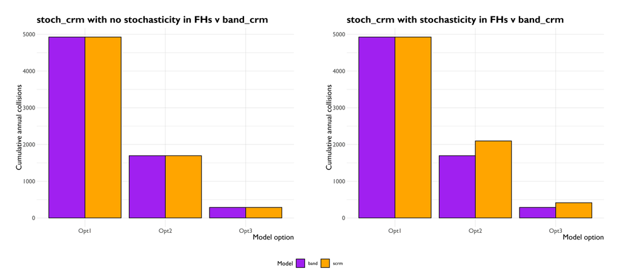

```r
# ------------------------------------------------------
# Run with arbitrary parameter values, for illustration
# ------------------------------------------------------
library(stochLAB)
# ------------------------------------------------------
# Setting some of the required inputs upfront

set.seed(999)
b_dens <- data.frame(
  month = month.abb,
  mean = runif(12, 0.8, 1.5),
  sd = runif(12, 0, 0)
)
head(b_dens)

# Generic FHD bootstraps from Johnson et al (2014)
# Select a SINGLE flight height bootstrap (i.e. one FH distribution)
# This scenario is for the LEFT-hand panel in the below figure.
fhd_boots <- generic_fhd_bootstraps[[1]][,1:2]


# Select ALL flight height bootstraps
# This scenario is for the RIGHT-hand panel in the below figure.
fhd_boots <- generic_fhd_bootstraps[[1]]


# wind speed vs rotation speed vs blade pitch
wind_rtn_ptch <- data.frame(
  wind_speed = seq_len(30),
  rtn_speed = 10/(30:1),
  bld_pitch = c(rep(90, 4), rep(0, 8), 5:22)
)
head(wind_rtn_ptch)

# wind availability
windavb <- data.frame(
  month = month.abb,
  pctg = runif(12, 85, 98)
)
head(windavb)

# maintenance downtime
dwntm <- data.frame(
  month = month.abb,
  mean = runif(12, 6, 10),
  sd = rep(0, 12))
head(dwntm)


# ----------------------------------------------------------
# Run stochastic CRM, treating rotor radius, air gap and
# blade width as fixed parameters (i.e. not stochastic)
stoch_output <- stoch_crm(
  model_options = c(1, 2, 3),
  n_iter = 1000,
  flt_speed_pars = data.frame(mean = 13.1, sd = 0),
  body_lt_pars = data.frame(mean = 0.85, sd = 0),
  wing_span_pars = data.frame(mean = 1.01, sd = 0),
  avoid_bsc_pars = data.frame(mean = 0, sd = 0),
  avoid_ext_pars = data.frame(mean = 0, sd = 0),
  noct_act_pars = data.frame(mean = 0.5, sd = 0),
  prop_crh_pars = data.frame(mean = 0.13, sd = 0),
  bird_dens_opt = "tnorm",
  bird_dens_dt = b_dens,
  flight_type = "flapping",
  prop_upwind = 0.5,
  gen_fhd_boots = fhd_boots,
  n_blades = 3,
  bld_pitch_pars = data.frame(mean = 15, sd = 0),
  rtn_speed_pars = data.frame(mean = 15, sd = 0),
  rtr_radius_pars = data.frame(mean = 120, sd = 0), # sd = 0, rotor radius is fixed
  air_gap_pars = data.frame(mean = 30, sd = 0),    # sd = 0, air gap is fixed
  bld_width_pars = data.frame(mean = 5, sd = 0),   # sd = 0, blade width is fixed
  rtn_pitch_opt = "probDist",
  windspd_pars = data.frame(mean = 7.74, sd = 0),
  rtn_pitch_windspd_dt = wind_rtn_ptch,
  trb_wind_avbl = windavb,
  trb_downtime_pars = dwntm,
  wf_n_trbs = 100,
  wf_width = 52,
  wf_latitude = 56.9,
  tidal_offset = 2.5,
  lrg_arr_corr = TRUE,
  verbose = TRUE,
  seed = 1234,
  out_format = "summaries",
  out_sampled_pars = TRUE,
  out_period = "months"
)


# Run Band model ----------------------------------------------------------


bd_dens <- data.frame(
  month = month.abb,
  dens = b_dens$mean
)

gen_fhd <- fhd_boots[,c(1:2)]
names(gen_fhd)[2] <- "prop"

prop_oper <- data.frame(
  month = month.abb,
  prop_oper = stoch_output$sampled_pars$prop_oper_mth$mean)


band_output <- band_crm(
  model_options = c(1,2,3),
  flight_speed = stoch_output$sampled_pars$flt_speed$mean,
  body_lt = stoch_output$sampled_pars$body_lt$mean,
  wing_span = stoch_output$sampled_pars$wing_span$mean,
  flight_type = "flapping",
  avoid_rt_basic = 0,
  avoid_rt_ext = 0,
  noct_activity = stoch_output$sampled_pars$noct_actv$mean,
  prop_crh_surv = stoch_output$sampled_pars$prop_crh$mean,
  dens_month = bd_dens,
  prop_upwind = 0.5,
  gen_fhd = gen_fhd,
  rotor_speed = stoch_output$sampled_pars$rtn_speed$mean,
  rotor_radius = stoch_output$sampled_pars$rtr_radius$mean,
  blade_width = stoch_output$sampled_pars$bld_width$mean,
  blade_pitch = stoch_output$sampled_pars$bld_pitch$mean,
  n_blades = 3,
  hub_height = 150,
  chord_prof = chord_prof_5MW,
  n_turbines = 100,
  turb_oper_month = prop_oper,
  wf_width = 52,
  wf_latitude = 56.9,
  tidal_offset = 2.5,
  lrg_arr_corr = TRUE,
  xinc=0.05,
  yinc=0.05
)
```